# ChIP-Seq – ChIP-seq annotation and visualization –

Denis Puthier

2016-10-26

## Notes about file format

### The BED format

One of the expected result of a peak calling approach (see previous tutorial) is a set of peaks in bed format. The **BED format** also known as **BED6 format** is **the most widely used**. The [BED6](https://genome.ucsc.edu/FAQ/FAQformat#format1) contains the following information:

- **chrom** - The name of the chromosome (e.g. chr3, chrY, chr2…).
- **chromStart** - The starting position of the feature in the chromosome.
- **chromEnd** - The ending position of the feature in the chromosome.
- **name** - A name for the feature (e.g. gene name…).
- **score** - A score between 0 and 1000.
- **strand** - - Defines the strand - either ‘+’ or ‘-’.

An example BED record is provided below.

| **chrom** | **start** | **end** | **name** | **score** | **strand** |
| --- | --- | --- | --- | --- | --- |
| chr1 | 123 | 789 | feature_1 | 0 | + |

An alternative is the the BED3 format that only contains the 3 first column.

| **chrom** | **start** | **end** |
| --- | --- | --- |
| chr1 | 123 | 789 |

Finally a less conventional Bed format is the **BED12** format that is most generally used to store transcript coordinates (including all exon coordinates).

Depending of the software producing the BED file, an additional first line (a header) containing a description can be found. See [UCSC BED format](https://genome.ucsc.edu/FAQ/FAQformat#format1) description for more information.

### Coordinate system is zero-based half-open

Several conventions exist to describe genome coordinates. The BED file format is said to be “zero-based, half-open”.

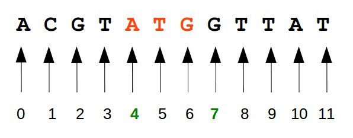

Zero-based means that the coordinate of the first nucleotide of a chromosome is defined as 0 . half-open means that the “End” coordinate is not part of the feature. In the example above, corresponding to a “chromosome” (Z) containing 12 nucleotides, the coordinates of the ATG (in red) sequence would be [4,7[. The corresponding entry would be described by the following row in a bed file **ChrZ 4 7**.

### What should I in case of trouble with my BED file ?

If you encounter issues with BED files in Galaxy you should try to:

- **Delete** the **header** line if it exists.
- **Convert** the file to a real BED6 format
  - Most of the time the file contains the 3 first column.
  - In some cases the order of the 3 last columns may be **swapped**.
  - Sometimes the “strand” information is **not available**. You may use the **add** tool from Galaxy to append a “.” to each line (indicating that strand is unknown).
- **Sort** the BED files.
- Although it is not always mentioned some tools required BED files to be sorted by genomic coordinates. This can be performed using **SortBED** from the Bedtools suite.

## Global objective

Given a set of ChIP-seq peaks annotate them in order to find associated genes, associated genomic elements (promoter, UTR, introns,…) and associated functional terms (through GO term analysis).

### Data set

For this practical session, the ChIP-seq data and peaks related to following publication will be used: “GATA3 acts upstream of FOXA1 in mediating ESR1 binding by shaping enhancer accessibility.”, [Theodorou *et al*](http://www.ncbi.nlm.nih.gov/pubmed/23172872).

The following pre-processed datasets are available:

#### MACS peaks

Each file contains 7 columns in “BED” format.

- **chrom** - The name of the chromosome (e.g. chr3, chrY, chr2…).
- **chromStart** - The starting position of the feature in the chromosome.
- **chromEnd** - The ending position of the feature in the chromosome.
- **name** - A name for the feature (e.g. gene name…).
- **score** - The MACS score, -log10(p-value).
- **strand** - - Defines the strand - either ‘+’ or ‘-’.
- **summit** - - The summit position in the bigwig file relative to chromStart.

| Sample | format |
| --- | --- |
| [siGATA_ER_E2_r1](http://pedagogix-tagc.univ-mrs.fr/courses/data/ngs/td_chip_seq/all/siGATA_ER_E2_r1_SRX176857_peaks.bed) | bed |
| [siGATA_ER_E2_r2](http://pedagogix-tagc.univ-mrs.fr/courses/data/ngs/td_chip_seq/all/siGATA_ER_E2_r2_SRX176859_peaks.bed) | bed |
| [siGATA_ER_E2_r3](http://pedagogix-tagc.univ-mrs.fr/courses/data/ngs/td_chip_seq/all/siGATA_ER_E2_r3_SRX176861_peaks.bed) | bed |
| [siGATA_H3K4me1_E2_r1](http://pedagogix-tagc.univ-mrs.fr/courses/data/ngs/td_chip_seq/all/siGATA_H3K4me1_E2_r1_SRX176879_broad_peaks.bed) | bed |
| [siNT_ER_E2_r1](http://pedagogix-tagc.univ-mrs.fr/courses/data/ngs/td_chip_seq/all/siNT_ER_E2_r1_SRX176856_peaks.bed) | bed |
| [siNT_ER_E2_r2](http://pedagogix-tagc.univ-mrs.fr/courses/data/ngs/td_chip_seq/all/siNT_ER_E2_r2_SRX176858_peaks.bed) | bed |
| [siNT_ER_E2_r3](http://pedagogix-tagc.univ-mrs.fr/courses/data/ngs/td_chip_seq/all/siNT_ER_E2_r3_SRX176860_peaks.bed) | bed |

#### BAM files

The BAM indexes are provided in the second table.

| Sample | format |
| --- | --- |
| [MCF_input_r3](http://pedagogix-tagc.univ-mrs.fr/courses/data/ngs/td_chip_seq/all/MCF_input_r3_SRX176888_sort.bam) | bam |
| [siGATA_ER_E2_r1](http://pedagogix-tagc.univ-mrs.fr/courses/data/ngs/td_chip_seq/all/siGATA_ER_E2_r1_SRX176857_sort.bam) | bam |
| [siGATA_ER_E2_r2](http://pedagogix-tagc.univ-mrs.fr/courses/data/ngs/td_chip_seq/all/siGATA_ER_E2_r2_SRX176859_sort.bam) | bam |
| [siGATA_ER_E2_r3](http://pedagogix-tagc.univ-mrs.fr/courses/data/ngs/td_chip_seq/all/siGATA_ER_E2_r3_SRX176861_sort.bam) | bam |
| [siGATA_H3K4me1_E2_r1](http://pedagogix-tagc.univ-mrs.fr/courses/data/ngs/td_chip_seq/all/siGATA_H3K4me1_E2_r1_SRX176879_sort.bam) | bam |
| [siNT_ER_E2_r1](http://pedagogix-tagc.univ-mrs.fr/courses/data/ngs/td_chip_seq/all/siNT_ER_E2_r1_SRX176856_sort.bam) | bam |
| [siNT_ER_E2_r2](http://pedagogix-tagc.univ-mrs.fr/courses/data/ngs/td_chip_seq/all/siNT_ER_E2_r2_SRX176858_sort.bam) | bam |
| [siNT_ER_E2_r3](http://pedagogix-tagc.univ-mrs.fr/courses/data/ngs/td_chip_seq/all/siNT_ER_E2_r3_SRX176860_sort.bam) | bam |
| [siNT_H3K4me1_E2_r1](http://pedagogix-tagc.univ-mrs.fr/courses/data/ngs/td_chip_seq/all/siNT_H3K4me1_E2_r1_SRX176878_sort.bam) | bam |

| Sample | format |
| --- | --- |
| [MCF_input_r3](http://pedagogix-tagc.univ-mrs.fr/courses/data/ngs/td_chip_seq/all/MCF_input_r3_SRX176888_sort.bam.bai) | bam |
| [siGATA_ER_E2_r1](http://pedagogix-tagc.univ-mrs.fr/courses/data/ngs/td_chip_seq/all/siGATA_ER_E2_r1_SRX176857_sort.bam.bai) | bam |
| [siGATA_ER_E2_r2](http://pedagogix-tagc.univ-mrs.fr/courses/data/ngs/td_chip_seq/all/siGATA_ER_E2_r2_SRX176859_sort.bam.bai) | bam |
| [siGATA_ER_E2_r3](http://pedagogix-tagc.univ-mrs.fr/courses/data/ngs/td_chip_seq/all/siGATA_ER_E2_r3_SRX176861_sort.bam.bai) | bam |
| [siGATA_H3K4me1_E2_r1](http://pedagogix-tagc.univ-mrs.fr/courses/data/ngs/td_chip_seq/all/siGATA_H3K4me1_E2_r1_SRX176879_sort.bam.bai) | bam |
| [siNT_ER_E2_r1](http://pedagogix-tagc.univ-mrs.fr/courses/data/ngs/td_chip_seq/all/siNT_ER_E2_r1_SRX176856_sort.bam.bai) | bam |
| [siNT_ER_E2_r2](http://pedagogix-tagc.univ-mrs.fr/courses/data/ngs/td_chip_seq/all/siNT_ER_E2_r2_SRX176858_sort.bam.bai) | bam |
| [siNT_ER_E2_r3](http://pedagogix-tagc.univ-mrs.fr/courses/data/ngs/td_chip_seq/all/siNT_ER_E2_r3_SRX176860_sort.bam.bai) | bam |
| [siNT_H3K4me1_E2_r1](http://pedagogix-tagc.univ-mrs.fr/courses/data/ngs/td_chip_seq/all/siNT_H3K4me1_E2_r1_SRX176878_sort.bam.bai) | bam |

#### Bigwig files

| Sample | format |
| --- | --- |
| [MCF_input_r3](http://pedagogix-tagc.univ-mrs.fr/courses/data/ngs/td_chip_seq/all/MCF_input_r3_SRX176888.bigWig) | bigWig |
| [siGATA_ER_E2_r1](http://pedagogix-tagc.univ-mrs.fr/courses/data/ngs/td_chip_seq/all/siGATA_ER_E2_r1_SRX176857.bigWig) | bigWig |
| [siGATA_ER_E2_r2](http://pedagogix-tagc.univ-mrs.fr/courses/data/ngs/td_chip_seq/all/siGATA_ER_E2_r2_SRX176859.bigWig) | bigWig |
| [siGATA_ER_E2_r3](http://pedagogix-tagc.univ-mrs.fr/courses/data/ngs/td_chip_seq/all/siGATA_ER_E2_r3_SRX176861.bigWig) | bigWig |
| [siGATA_H3K4me1_E2_r1](http://pedagogix-tagc.univ-mrs.fr/courses/data/ngs/td_chip_seq/all/siGATA_H3K4me1_E2_r1_SRX176879.bigWig) | bigWig |
| [siNT_ER_E2_r1](http://pedagogix-tagc.univ-mrs.fr/courses/data/ngs/td_chip_seq/all/siNT_ER_E2_r1_SRX176856.bigWig) | bigWig |
| [siNT_ER_E2_r2](http://pedagogix-tagc.univ-mrs.fr/courses/data/ngs/td_chip_seq/all/siNT_ER_E2_r2_SRX176858.bigWig) | bigWig |
| [siNT_ER_E2_r3](http://pedagogix-tagc.univ-mrs.fr/courses/data/ngs/td_chip_seq/all/siNT_ER_E2_r3_SRX176860.bigWig) | bigWig |
| [siNT_H3K4me1_E2_r1](http://pedagogix-tagc.univ-mrs.fr/courses/data/ngs/td_chip_seq/all/siNT_H3K4me1_E2_r1_SRX176878.bigWig) | bigWig |

### Loading the data

Reload IGV. **Load the bigWig files and bed files** in the genome browser. Use colored tracks to distinguish between GATA3 KO and WT condition (**right-click on track name > Change track color**). **Reorder properly** the files with peaks below corresponding bigwigs.

- What about the H3K4me1 track ? Does it looks like ESR1 track ?
- Using galaxy search for the most enriched peak relative to input (best score) for one ESR1 sample and one H3K4me1 sample. Use tool named: **Sort data in ascending or descending order**.
- Using galaxy, draw the distribution of peak size for ESR1 and H3K4me1. Do they look the same. Use the **cut** and **histogram** command.
- For each bed the 7th column contains the summit position relative to the start position. For one sample convert it to a bed format and load it into IGV. Use **Compute an expression on every row** tool and **cut**.
- Extend the summit position by 100 nucleotides in 5’ and 3’ using bedtools **SlopBed** . Load the result in IGV.

## Comparing replicates

Reproducibility may be an issue in ChIP-Seq experiment. Select one condition (WT or GATA KO).

- What are the number of peaks in each replicate.
- Using intersectBed (tool **Intersect intervals**) from the Bedtools suite (available in Galaxy or command line), compute the number of peaks shared by the 3 replicates (WT or KO).
- Create a bed file containing peaks that overlap in all tree replicates.

## Relate peaks to GO terms

For that specific step we will use the GREAT annotation tools. Connect to [GREAT web server](http://great.stanford.edu) and perform a GO annotation for the ESR1 peaks. Alternatively GREAT can be launch directly from UCSC web server (using Table browser Custom track and by selecting send to GREAT).

- **WARNING** GREAT REQUIRED A BED6 FORMAT WITHOUT ANY ADDITIONAL COLUMN.
- Connect the [GREAT](http://great.stanford.edu) web server http://great.stanford.edu
- select the genome assembly version (hg19)
- Upload or paste the peaks obtained previously in BED format (e.g intersect from the 3 replicates).
- use the whole genome as background and run the software
- Try using other parameters (“marked” regions). What about the results ?
- Check the result with a negative control (use randomBed in Galaxy to produce random regions).

Examine the enriched functional categories ? Are they biologically meaningful given what you know about ESR1 ?

## Get the name of the closest transcript for each peak

It may be interesting, for each peak, to get the name of the closest transcript. Two this aim we require both transcript coordinates and a set of peaks in BED format. We will search the closest feature using the closestBed tool from Bedtools suite.

### Getting the coordinates of all the genes in the reference genome

- Open a connexion to Galaxy
- In the Tool search box, look for UCSC main table browser
  - Choose the right **genome version** (e.g. hg19 for the study case)
  - **Group**: *genes and gene predictions*
  - **Track**: the *Refseq* genes are shared between several databases.
    - **Note**: refseq IDs refers to a sequence, not a gene, so if the same sequence is duplicated on the genome, sometimes the same refseq ID ill be associated to different positions.
  - **Output format**: bed
  - **Send output to:** Galaxy
  - Submit the query.
  - This opens a new form to specify the output parameters. Check the option **Whole gene**.

So far, we obtained the list of all the Human transcripts, in **bed12** format. This format includes, in addition to the genomic coordinates (columns 1-3), the transcript ID, coordinates of the coding region, number of exons, list of exon starts and list of exon ends.

We would like to select the 6 first columns to clearly visualized in IGV the selected regions.

- In the Tool search box, look for the tool named *cut* and open its form
- Set **Cut columns** to c1, c2, c3,c4,c5,c6
- Select **From** option and point to the bed12 file containing the coordinates of all the transcripts.
- Now convert this **tabular file** back into a **Bed** file by using:
  - **edit attributes > Convert format > Convert genomic intervals to BED**
- Download the file and load it into IGV.
- What are the region that is spanned by the bed file ?
- Is that what we need for subsequent analysis ?

### Search for closest gene using Bedtools

Bedtools requires the BED file to bed sorted.

- Use sortBed to create a sorted version
- Is that what we need for subsequent analysis ?

### Using CEAS

In the TAGC galaxy instance. CEAS (Cis-regulatory Element Annotation System) is a tool for characterizing genome-wide protein-DNA interaction patterns from ChIP-chip and ChIP-Seq of both sharp and broad binding factors. It provides statistics on ChIP enrichment at important genome features such as specific chromosome, promoters, gene bodies, or exons, and infers genes most likely to be regulated by a binding factor.

- Select **NGS: Peak Calling > CEAS Annotate intervals and scores with genome features**.
- Use the appropriate settings and click **Execute**.

What can we say about the enrichment.

## Visualize ChIP enrichment around a given feature

Using the “deepTools heatmapper” we will try to visualize the local enrichment around the TSS for all known genes. Before drawing the heatmap we need to prepare the data by computing a summary matrix of the local ChIP enrichment using “deepTools computeMatrix”.

- Download the required annotation file (here all UCSC annotated genes) from the UCSC genome browser (go to Table Browser, UCSC Genes and download the annotation as bed file. Save this locally).
- Use the obtained annotation file and the previously computed bigWig profile (from your history) as an input to “computeMatrix”. You could select for instance H3K4me1.
- Use ‘reference point’ as the output option and ‘beginning of region’ as this reference point (TSS).
- Using the “heatmapper”, load the obtained matrix data and fill the desired options to plot the heat map.
- Perform the analysis both with a ChIP for a chromatin mark and a transcription factor.

Do you see any differences between the two choosen dataset ?

## Integrative ChIP-seq analysis of regulatory elements

In this part, we will use the ReMap (http://tagc.univ-mrs.fr/remap/index.php) software to compare the peaks obtained in the peaks calling tutorial to an extensive regulatory catalog of 8 million transcription factor binding regions defined by collecting all the peaks from ChIP-seq experiments from the ENCODE project + other public datasets from the GEO database. Note that on the ReMap Web site, the term “site” is used to denote a ChIP-seq peak, rather than the precise binding location of a transcription factor

- Connect the [ReMap](http://tagc.univ-mrs.fr/remap/index.php) web server
- Go to the Annotation Tool
- upload or paste the peaks in BED format (select BED format in the data format selector)
- Add your email and run the software with default parameters

What are the TFs associated to your peaks?

## Some idea for your project

- Analyse inter-replicate reproducibility.
- Impact of MACS score (-log10(p-value)) on motif discovery ?
- Impact of genomic location (intragenic, intergenic, promoter,…) on the discovery of alternative motifs.
- Differential analysis using ad-hoc software.
- Are there any genomic bias in peak appearing/disappearing in GATA KO condition ?
- Impact of the select region of the peak on motif discovery. Does summit +/- n bp provide better result than full peak ?
- Are there any genomic bias related to peak size ? If yes, is that related to a given condition ?